# Visium HD tutorial

We can run Sopa on Visium HD, as the 2 micron bins are subcellular. It uses similar functions as in the "normal" API tutorial.

For this tutorial, we use the [mouse small intestine public dataset](https://www.10xgenomics.com/datasets/visium-hd-cytassist-gene-expression-libraries-of-mouse-intestine) from 10X Genomics.

```python
import spatialdata

import sopa
```

import spatialdata import sopa

## Reading the data

You can read your Visium HD data with `sopa.io.visium_hd`.

**Important notes**:

- This API tutorial assumes you already ran Space Ranger. If you didn't, you can consider running the full sopa pipeline for Visium HD via Nextflow (see [`nf-core/sopa`](https://nf-co.re/sopa/dev/))
- If Space Ranger produced files with no prefix (for instance, `feature_slice.h5`), then pass `dataset_id=""` to the reader below.
- If your full resolution microscopy image is not stored in the `microscope_image`, you need to provide `fullres_image_file` as below. Else, it will be found automatically. This is not necessary if you have prior 10X Genomics segmentation (in which case you can diectly use proseg).

```python
sdata = sopa.io.visium_hd(
    "data/visium_hd/Visium_HD_Mouse_Small_Intestine",  # Space Ranger output directory
    fullres_image_file="/path/to/microscopy/image.tiff",  # not needed for this tuto
    dataset_id="",  # only if Space Ranger produced files with no prefix
)

sdata
```

sdata = sopa.io.visium_hd( "data/visium_hd/Visium_HD_Mouse_Small_Intestine", # Space Ranger output directory fullres_image_file="/path/to/microscopy/image.tiff", # not needed for this tuto dataset_id="", # only if Space Ranger produced files with no prefix ) sdata

Then, we save it on-disk:

```python
sdata.write("mouse_small_intestine.zarr")  # save it

sdata = spatialdata.read_zarr("mouse_small_intestine.zarr")  # open-it back
```

sdata.write("mouse_small_intestine.zarr") # save it sdata = spatialdata.read_zarr("mouse_small_intestine.zarr") # open-it back

## Option 1: running StarDist

The first option is to run [Stardist](https://github.com/stardist/stardist) on the H&E image. Note that, to do that, you'll need the full-resolution image. Else, if you have a prior 10X segmentation, you can directly go to the Proseg section.

First, we create the patches for the cell segmentation.

```python
sopa.make_image_patches(sdata)
```

sopa.make_image_patches(sdata)

```
[INFO] (sopa.patches._patches) Added 156 patche(s) to sdata['image_patches']
```

Now we can run stardist on the H&E image.

```python
sopa.segmentation.stardist(sdata, min_area=30)
```

sopa.segmentation.stardist(sdata, min_area=30)

```
[WARNING] (sopa._settings) Running without parallelization backend can be slow. Consider using a backend, e.g. via `sopa.settings.parallelization_backend = 'dask'`, or `export SOPA_PARALLELIZATION_BACKEND=dask`.
```

[output not shown]

[output not shown]

```
[INFO] (sopa.segmentation._stainings) Found 430536 total cells
[INFO] (sopa.segmentation._stainings) Added 410196 cell boundaries in sdata['stardist_boundaries']
```

## Option 2: running Proseg

You can use [`proseg`](https://github.com/dcjones/proseg) to use the bins information to improve the segmentation and aggregation. To do so, `proseg` needs a prior segmentation: you can either use `stardist` (see how to run it above), or directly use the 10X Genomics default segmentation available on the recent Visium HD versions.

Using `prior_shapes_key="auto"` will automatically detect which segmentation to use. If you ran `stardist`, it will use it as a prior, else it will fallback to the default 10X Genomics segmentation.

**NB: this feature is still experimental, and was added in `sopa==2.1.10`. Ensure you read your data with `sopa.io.visium_hd` using `sopa>=2.1.10`**.

```python
sopa.segmentation.proseg(sdata, prior_shapes_key="auto")
```

sopa.segmentation.proseg(sdata, prior_shapes_key="auto")

Since `proseg` already aggregate the bins inside the cells, the next section (i.e., aggregation) is not mandatory.

## Aggregation

Now, we can run `sopa.aggregate` to aggregate the bins into the cells. **This is mandatory if you used stardist only**, but optional if you ran proseg. Even if you used proseg, it can still be useful it if you want some additional aggregation or filtering.

For each cell, we expand their radius, and then Sopa will sum the transcript counts of all 2-microns-bins touching or included within the cell.

Here, `expand_radius_ratio = 1`, which means that the cells will be expanded a value of `1 * mean_radius` before aggregating the means. You can choose any positive float value. If you ran proseg, it will only be used for channel aggregation, since the transcripts are already aggregated.

> Note: There is an argument `bins_key`, but by default Sopa will understand that it's Visium HD data and that it should use the 2-microns bins. Also, on the example below, we only aggregate the bins, not the H&E channels.

> Note 2: You can also provide `no_overlap=True` to force each bin being mapped to only one cell.

```python
sopa.aggregate(sdata, aggregate_channels=False, expand_radius_ratio=1)
```

sopa.aggregate(sdata, aggregate_channels=False, expand_radius_ratio=1)

## Single-cell table

Now, we have an AnnData object with the gene expression **per cell**.

```python
adata = sdata["table"]
adata
```

adata = sdata["table"] adata

```
AnnData object with n_obs × n_vars = 408458 × 19059
    obs: 'region', 'slide', 'cell_id', 'area'
    var: 'gene_ids', 'feature_types', 'genome'
    uns: 'sopa_attrs', 'spatialdata_attrs'
    obsm: 'spatial'
```

For instance, we can now use Scanpy to plot gene expression.

```python
import scanpy as sc
```

import scanpy as sc

```python
# basic preprocessing
sc.pp.filter_genes(adata, min_cells=10)
sc.pp.filter_cells(adata, min_counts=20)
sc.pp.normalize_total(adata)
sc.pp.log1p(adata)
```

# basic preprocessing sc.pp.filter_genes(adata, min_cells=10) sc.pp.filter_cells(adata, min_counts=20) sc.pp.normalize_total(adata) sc.pp.log1p(adata)

We can then use `sc.pl.spatial` to show the gene expression per cells. Note that, here, we show **cells**, not bins.

```python
sc.pl.spatial(adata, color="Tpm2", spot_size=80, vmax="p98")
```

sc.pl.spatial(adata, color="Tpm2", spot_size=80, vmax="p98")

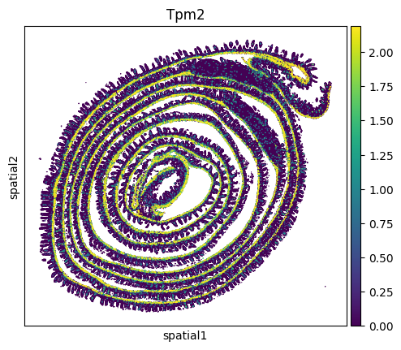

## Bins visualization

The 2-micron bins are arranged in a grid, so they can be visualized as an image of `G` channels, where `G` is the number of genes.

Creating the image would be massive, so we need to create it lazily. This can be done with `spatialdata.rasterize_bins`.

```python
sdata["square_002um"].X = sdata["square_002um"].X.tocsc()  # optimisation with the csc format

lazy_bins_image = spatialdata.rasterize_bins(
    sdata,
    bins="Visium_HD_Mouse_Small_Intestine_square_002um",  # key of the bins shapes
    table_name="square_002um",  # key of the table with the bins gene expression
    row_key="array_row",
    col_key="array_col",
)
```

sdata["square_002um"].X = sdata["square_002um"].X.tocsc() # optimisation with the csc format lazy_bins_image = spatialdata.rasterize_bins( sdata, bins="Visium_HD_Mouse_Small_Intestine_square_002um", # key of the bins shapes table_name="square_002um", # key of the table with the bins gene expression row_key="array_row", col_key="array_col", )

Note that `lazy_bins_image` is an image of size `(19059, 690, 690)`, that is `G=19059` genes, and `690x690` bins. This would correspond to a 33.80GB image in memory, if it wasn't lazy.

```python
lazy_bins_image
```

lazy_bins_image

We can save this image in the `sdata` object.

```python
sdata["gene_expression_2_um"] = lazy_bins_image
```

sdata["gene_expression_2_um"] = lazy_bins_image

Then, we can visualize this image with Napari. When showing a gene, it will compute the corresponding layer of the lazy image, and it will be displayed in milliseconds, i.e. looking instantaneous.

```python
from napari_spatialdata import Interactive

Interactive(sdata)
```

from napari_spatialdata import Interactive Interactive(sdata)

You'll be able to display cells and the bins expression. It should look like that:

[figure not shown]

## Xenium Explorer

Although the Xenium Explorer can be used (as below), it will not display the bins. If you want to see the bins, use `Napari` as detailed above.

```python
sopa.io.explorer.write("mouse_small_intestine.explorer", sdata)
```

sopa.io.explorer.write("mouse_small_intestine.explorer", sdata)

```
[INFO] (sopa.io.explorer.table) Writing table with 18166 columns
[INFO] (sopa.io.explorer.table) Writing 2 cell categories: region, slide
[INFO] (sopa.io.explorer.shapes) Writing 332556 cell polygons
[INFO] (sopa.io.explorer.images) Writing multiscale image with procedure=semi-lazy (load in memory when possible)
[INFO] (sopa.io.explorer.images)    (Loading image of shape (3, 21943, 23618)) in memory
[INFO] (sopa.io.explorer.images)    > Image of shape (3, 21943, 23618)
[INFO] (sopa.io.explorer.images)    > Image of shape (3, 10971, 11809)
[INFO] (sopa.io.explorer.images)    > Image of shape (3, 5485, 5904)
[INFO] (sopa.io.explorer.images)    > Image of shape (3, 2742, 2952)
[INFO] (sopa.io.explorer.images)    > Image of shape (3, 1371, 1476)
[INFO] (sopa.io.explorer.images)    > Image of shape (3, 685, 738)
[INFO] (sopa.io.explorer.converter) Saved files in the following directory: mouse_small_intestine.explorer
[INFO] (sopa.io.explorer.converter) You can open the experiment with 'open mouse_small_intestine.explorer/experiment.xenium'
```